# RMarkdown Introduction

16/03/2021

## Session Outline

- Introduction
- Back-end Process
- Types of outputs & Benefits
- Basic Structure
- Live Demonstration

## Introduction

This presentation has been produced in R Markdown.

R Markdown is part of the RStudio suite and is available in standard RStudio and RStudio server.

It enables users to quickly produce dynamic documents.

Combines the core syntax of markdown with embedded R code chunks so their output can be included in the final document

## Back-end Process

[figure not shown]

Rmd: A combination of markdown and R Chunks

Knitr: The engine which executes the R code within a markdown documents and combines to create overall md

Pandoc: A free and open-source programme which converts documents types. In this case md to X,Y,Z

## Types of output and uses

R Markdown supports outputs formats such as HTML, PDF, MS Word & PowerPoint & websites

Manage and disseminate EDA or DS projects with fully reproducible R Markdown documents.

Integrate python scripts and objects within R. Other languages can also be used such as SQL, Shell.

Automate the generation of interactive reports and dashboards with custom template design.

Interact with HTML to create automated email report or create conditional parameterised reports.

## Basic Structure

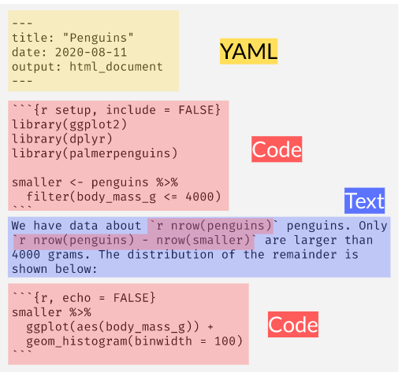

## Further Reading

Ultimate Guide: R Markdown e-book https://bookdown.org/yihui/rmarkdown/

R Markdown CookBook https://bookdown.org/yihui/rmarkdown-cookbook/

Cheat sheet https://rstudio.com/wp-content/uploads/2016/03/rmarkdown-cheatsheet-2.0.pdf

## Live Demo

This is my first ever live demo…